# Lecture 19 - Miscelenious

[Nao Mimoto](http://gozips.uakron.edu/~nmimoto/) - [Dept. of Statistics](http://www.uakron.edu/stat/) : [The University of Akron](http://www.uakron.edu)

Mar 14 2018

[Class Web Page](http://gozips.uakron.edu/~nmimoto/477/index.html)

[R resource page](http://gozips.uakron.edu/~nmimoto/R/index.html)

# 1. Box-Cox Transformation

Cryer p101

- Box-Cox Transformation function
  $$g(x) \hspace3mm = \hspace3mm
  \left\{
  \begin{array}{ll}
  \frac{x^\lambda - 1}{\lambda}& \mbox{ for } \lambda \ne 0 \\
  \log(x) & \mbox{ for } \lambda = 0 \\
  \end{array} \right.$$
- One can show
  $$\frac{x^\lambda - 1}{\lambda} \to \log(x) \hspace10mm \mbox{ as } \lambda \to 0.$$
- Sometimes called Normalizing Transformation
- This transformation is for positive data only.
- If data has negative observations, add a constant.
- You can try $\pm 1, \pm1/2, \pm 1/3, \pm 1/4, 0$ and see if it helps.
- To see what value of $\lambda$ makes the observation looks most normal, you can use

```r
    acf1 <- acf; library(TSA); acf  <- acf1  #- Load TSA package for BoxCox.ar()

    X <- rlnorm(1000)              # generate Log-normal data
    Find.lambda <- BoxCox.ar(X)    # Find best (most normalizing) B-C transformation parameter
```

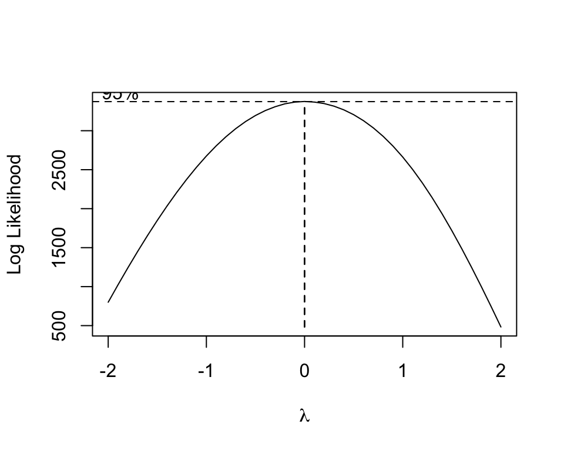

```r
    Find.lambda$mle
```

```
## [1] 0
```

## Ex: Annual Copper Price

- Setting **lambda=** option inside **Arima()** or **auto.arima()** Uses power transformation before the estimation, and transforms it back afterwards when predicting.
- Annual Copper Price - from Lecture 11.

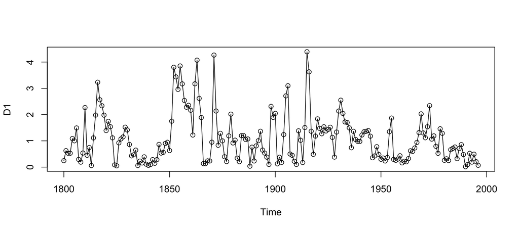

```r
  library(forecast)
  source("http://gozips.uakron.edu/~nmimoto/477/TS_R-90.txt")

  D  <- read.csv("http://gozips.uakron.edu/~nmimoto/pages/datasets/copper.csv")
  D1 <- ts(D[,2], start=c(1800,1), freq=1)
  plot(D1, type='o')
```

```r
  Fit1 <- auto.arima(D1, stepwise=FALSE)
  Fit1
```

```
## Series: D1
## ARIMA(1,0,1) with non-zero mean
##
## Coefficients:
##          ar1     ma1    mean
##       0.4938  0.2694  1.0771
## s.e.  0.0881  0.0938  0.1229
##
## sigma^2 estimated as 0.486:  log likelihood=-207.24
## AIC=422.49   AICc=422.7   BIC=435.62
```

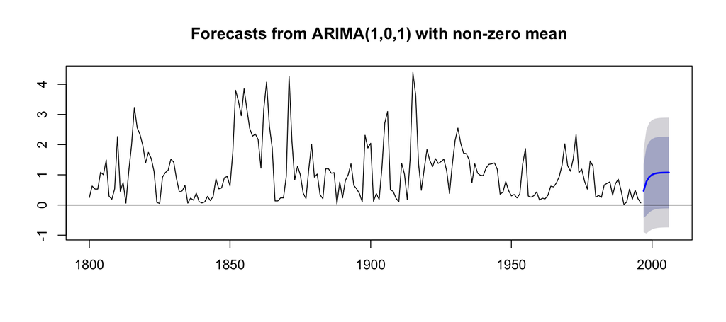

```r
  plot(forecast(Fit1))
  abline(h=0)
```

```r
  Fit2 <- auto.arima(D1, lambda=0, stepwise=FALSE)  # takes log-transformation inside
  Fit2
```

```
## Series: D1
## ARIMA(1,0,0) with non-zero mean
## Box Cox transformation: lambda= 0
##
## Coefficients:
##          ar1     mean
##       0.5334  -0.3649
## s.e.  0.0611   0.1357
##
## sigma^2 estimated as 0.8064:  log likelihood=-257.5
## AIC=521   AICc=521.13   BIC=530.85
```

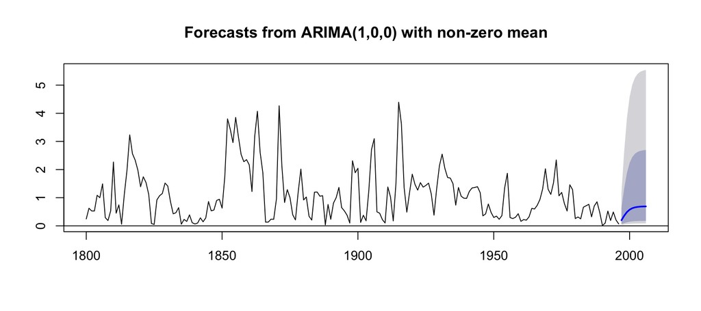

```r
  plot(forecast(Fit2))                              # already-
  abline(h=0)
```

```r
  Fit3 <- auto.arima(log(D1), stepwise=FALSE)
  Fit3
```

```
## Series: log(D1)
## ARIMA(1,0,0) with non-zero mean
##
## Coefficients:
##          ar1     mean
##       0.5334  -0.3649
## s.e.  0.0611   0.1357
##
## sigma^2 estimated as 0.8064:  log likelihood=-257.5
## AIC=521   AICc=521.13   BIC=530.85
```

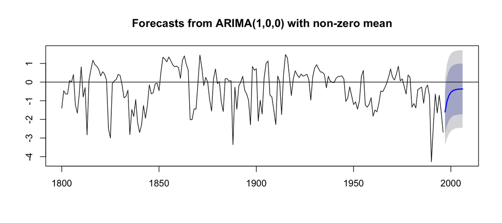

```r
  plot(forecast(Fit3))
  abline(h=0)
```

# 2. Conditional Moments

```r
  X  <- arima.sim(n = 500, list(ar = c(.8), ma = c(.5, .2)), sd=1.5) + 5


  library(FitARMA)
  Gam <- TacvfARMA(phi=c(.8), theta=c(-.5, -.2)) * 1.5^2     # watch the theta sign
  Gam[1]
```

```
## [1] 15.6625
```

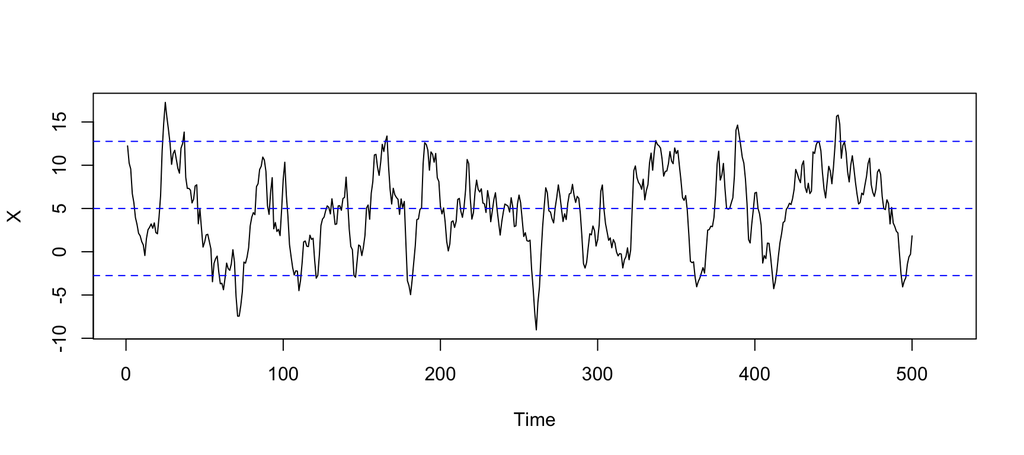

```r
  plot(X, xlim=c(0,520))
  abline(h=5+c(-1,0,1)*1.96*sqrt(Gam[1]), col="blue", lty=2)
```

# 3. OLS, GLS and Regressing TS

## OLS

From the regression model
$$\mathbf Y = \mathbf X \mathbf \beta + \mathbf \epsilon$$
* Ordinary Least Square minimizes the sum of squares, $(\mathbf Y - \mathbf X \mathbf \beta )'(\mathbf Y - \mathbf X \mathbf \beta )$,

- Which result in the estimator,
  $$\hat{\mathbf \beta } = (\mathbf X' \mathbf X)^{-1} \mathbf X' \mathbf Y.$$

## GLS

- Minimizes weighted sum of squares,
  $$( \mathbf Y - \mathbf X \mathbf \beta )' \mathbf \Gamma_n^{-1}
  (\mathbf Y - \mathbf X \mathbf \beta )$$
- $$\hat{\mathbf \beta } \hspace3mm = \hspace3mm
  (\mathbf X' \mathbf \Gamma_n^{-1} \mathbf X)^{-1} \mathbf X' \mathbf \Gamma_n^{-1} \mathbf Y.$$
- If $\mathbf X$ is non-random, we have $E( \hat{\mathbf \beta}) \hspace3mm = \hspace3mm \mathbf \beta$ and
  $$V (\hat{\mathbf \beta }) \hspace3mm = \hspace3mm
  (\mathbf X' \mathbf X)^{-1} \mathbf X' \mathbf \Sigma \mathbf X
  (\mathbf X' \mathbf X)^{-1} .$$
- For OLS, $\mathbf \Sigma = \sigma^2 \mathbf I$, and
  $$V (\hat{\mathbf \beta }) = \sigma^2 (\mathbf X' \mathbf X)^{-1} .$$
- For GLS, $\mathbf \Sigma = \mathbf \Gamma_n$, and
  $$V (\hat{\mathbf \beta }) = (\mathbf X' \mathbf \Gamma_n^{-1} \mathbf X)^{-1} .$$
  It can be shown that GLS estimator is the best linear unbiased estimator of $\mathbf \beta$. Therefore, GLS is better than OLS, but we need $\mathbf \Gamma_n$.

## Iterative Regression Scheme

- Compute OLS. Get residuals.
- Fit ARMA model to the residuals by Gaussian Maximum Likelihood.
- Using the fitted model, calculate $\mathbf \Gamma_n$. Go back to the original series, compute GLS.
- Repeat from 2.

## Ex: OLS and GLS

```r
  D  <- read.csv("http://gozips.uakron.edu/~nmimoto/pages/datasets/gtemp.csv")
  X  <- ts(D, start=c(1880), freq=1)
  plot(X, type='o')

  Reg1 <- lm(X~ time(X));  summary(Reg1)
  plot(Reg1$residuals)

  library(forecast)
  Fit1 <- auto.arima(Reg1$residuals)
  Fit1$coef

  library(nlme)
  cs1 <- corARMA(Fit1$coef, p=1,q=2)*Fit1$sigma
  Reg2 <- gls(X~t, correlation=cs1)
  Reg2
  Reg1
  Fit2 <- auto.arima(Reg2$residuals)
  Fit2
  Fit1


  cs2 <- corARMA(Fit2$coef, p=0,q=2)*Fit2$sigma
  Reg3 <- gls(X~t, correlation=cs2)
  Reg3
  Reg1
  Fit3 <- auto.arima(Reg3$residuals)
  Fit3

  Fit1

  Randomness.test(Fit3$residuals)
```

# 4. Regressing TS to TS

Sometimes, you want to model your TS lniarly dependaent on other time series.

- Sales depends on Global Economy
- Utility Demand depends on Temparature
- Level of toxin depends on local industory production
- In that case, your Model is that the time series of interest $X_t$, has linear relstionship with your independent series $B_t$, plus stationary noise. In the vector notation,
  $$X_t \hspace3mm = \hspace3mm \mathbf \beta \mathbf B_t + Y_t \\
  Y_t \sim ARMA$$
  where $x_t$ contains the “explanatory” TS.
- In scalar notation,
  $$X_t \hspace3mm = \hspace3mm a + b B_t + Y_t \hspace10mm Y_t \sim ARMA$$
  where $x_t$ contains the “explanatory” TS.

## Ex: Sales Data and Indicator

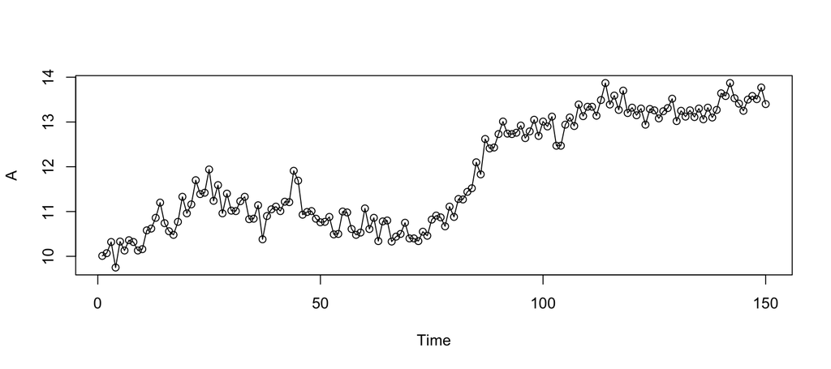

```r
  #- Indicator and Sales -
  D  <- read.table("http://gozips.uakron.edu/~nmimoto/pages/datasets/LS2.csv", header=T)
  A <- ts(D[,"Index"], start=c(1,1), freq=1)
  Sales <- ts(D[,"Sales"], start=c(1,1), freq=1)

  #- plot of Sales and index -
  plot(A, type='o')
```

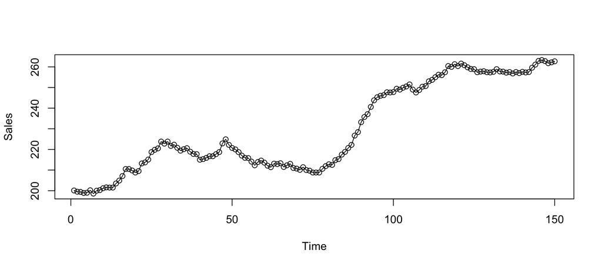

```r
  plot(Sales, type='o')
```

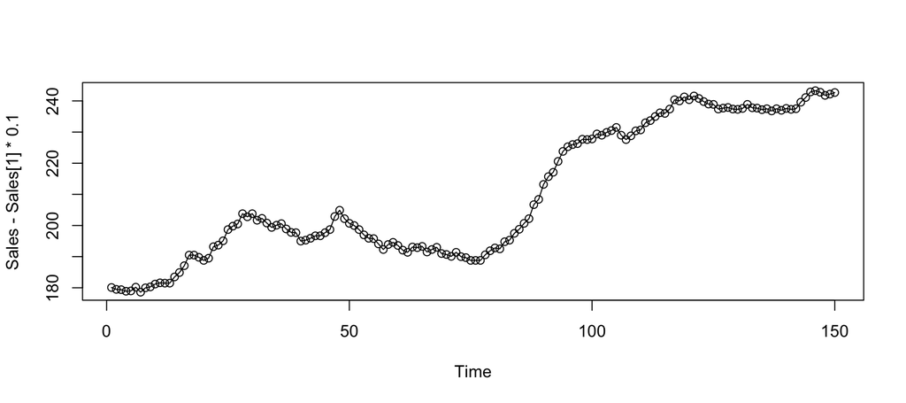

```r
  plot(Sales-Sales[1]*.1, type='o')
  lines((A-A[1]), col="red")     #- play around with *.1 part
```

```r
  #- Regress B on A
  Reg1 <- lm(Sales~A)
  summary(Reg1)
```

```
##
## Call:
## lm(formula = Sales ~ A)
##
## Residuals:
##      Min       1Q   Median       3Q      Max
## -20.7736  -4.2953   0.2078   5.1369  13.5720
##
## Coefficients:
##             Estimate Std. Error t value Pr(>|t|)
## (Intercept)  30.8812     5.3308   5.793 4.01e-08 ***
## A            16.8060     0.4476  37.544  < 2e-16 ***
## ---
## Signif. codes:  0 '***' 0.001 '**' 0.01 '*' 0.05 '.' 0.1 ' ' 1
##
## Residual standard error: 6.644 on 148 degrees of freedom
## Multiple R-squared:  0.905,  Adjusted R-squared:  0.9043
## F-statistic:  1410 on 1 and 148 DF,  p-value: < 2.2e-16
```

```r
  Reg2 <- lm(Sales~0+A)  #- no intercept
  summary(Reg2)
```

```
##
## Call:
## lm(formula = Sales ~ 0 + A)
##
## Residuals:
##     Min      1Q  Median      3Q     Max
## -22.449  -4.624   0.917   5.280  17.675
##
## Coefficients:
##   Estimate Std. Error t value Pr(>|t|)
## A 19.38579    0.05028   385.5   <2e-16 ***
## ---
## Signif. codes:  0 '***' 0.001 '**' 0.01 '*' 0.05 '.' 0.1 ' ' 1
##
## Residual standard error: 7.334 on 149 degrees of freedom
## Multiple R-squared:  0.999,  Adjusted R-squared:  0.999
## F-statistic: 1.486e+05 on 1 and 149 DF,  p-value: < 2.2e-16
```

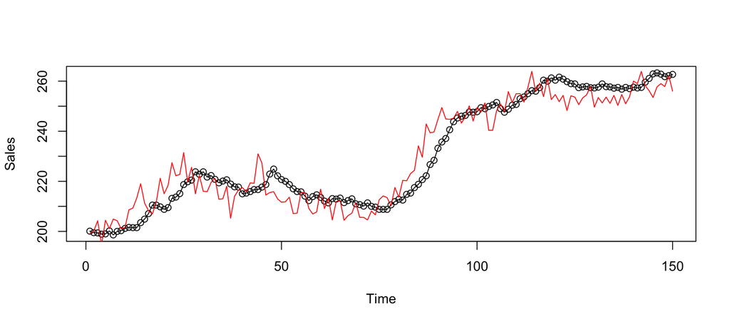

```r
  plot(Sales, type="o")
  lines(A*16.8+30.88, col="red")
```

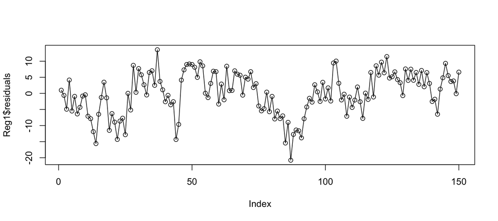

```r
  plot(Reg1$residuals, type="o")
```

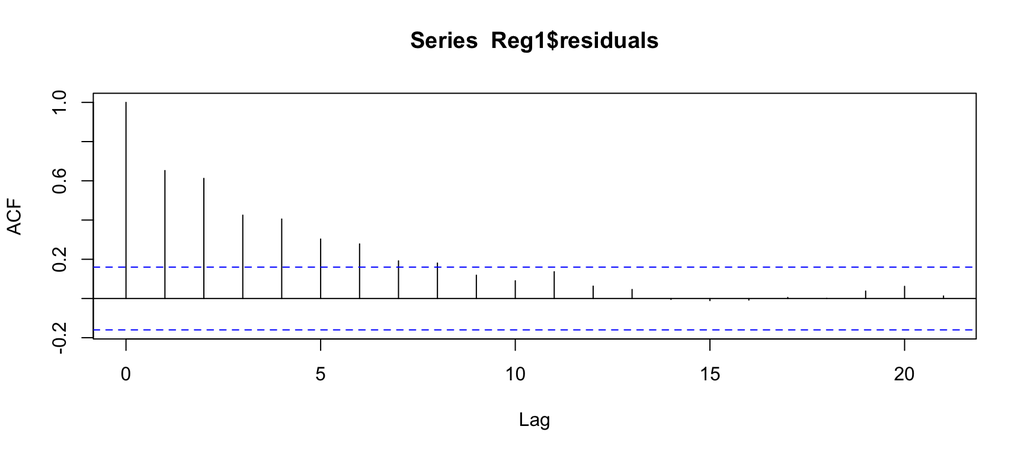

```r
  acf(Reg1$residuals)
```

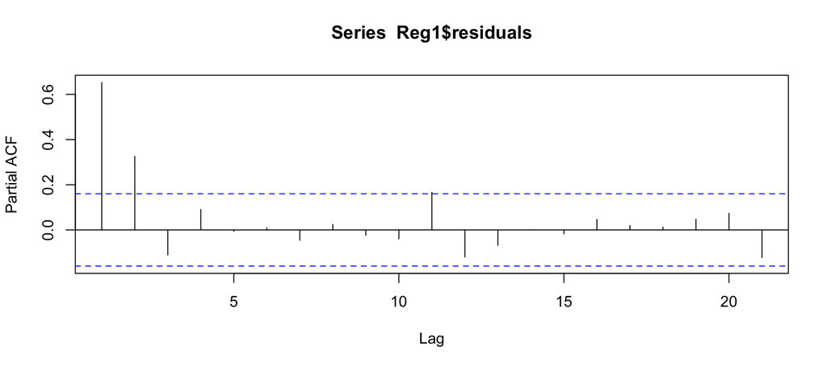

```r
  pacf(Reg1$residuals)
```

```r
  #- Model the residual
```

- We must worry about what’s called spurious regression
- Also called Cointegration Problem
- Residuals out of TS-TS regression must be stationary